# Plotting Random Effects of Mixed Models

Daniel Lüdecke

2017-02-03

This document shows examples for `sjp.lmer()`, especially the plot-types for plotting random effects. For other plot-types like effect-plots or predictions, see this vignette.

```r
# load packages
library(sjPlot)
library(sjmisc)
# load sample data set.
data(efc)
set_theme(theme = "forest",
          geom.label.size = 3,
          axis.textsize = .9,
          axis.title.size = .9)
```

## Plotting random effects of linear mixed effects models

`sjp.lmer()` plots effects of `merMod` objects, which were fitted using the `lmer()` function of the **lme4** package.

First, we need fit a sample model.

```r
# fit model
library(lme4)
fit <- lmer(Reaction ~ Days + (Days | Subject), sleepstudy)

# prepare group variable
efc$grp = as.factor(efc$e15relat)
levels(x = efc$grp) <- get_labels(efc$e15relat)
# data frame for fitted model
mydf <- data.frame(neg_c_7 = efc$neg_c_7,
                   sex = to_factor(efc$c161sex),
                   c12hour = efc$c12hour,
                   barthel = efc$barthtot,
                   grp = efc$grp)
# fit 2nd model
fit2 <- lmer(neg_c_7 ~ sex + c12hour + barthel + (1 | grp), data = mydf)
```

By default, random effects are plotted. In this example, the random effects of random intercept and random coefficient(s) are plotted as an integrated (faceted plot.) Note that the `y.offset` argument is used to adjust the value label position. Depending on text size and screen resolution, the default position of text labels may vary.

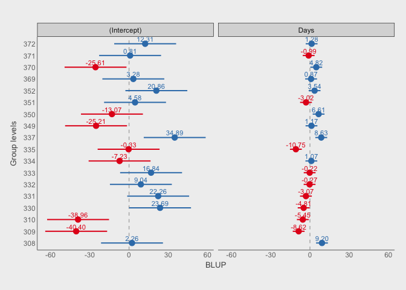

```r
sjp.lmer(fit, y.offset = .4)
```

With the `sort.est` argument you can specify the random intercept or any random coefficient in order to sort the effects accordingly.

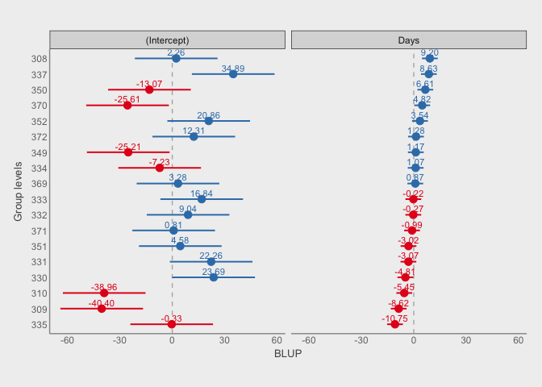

```r
# sort by predictor Days
sjp.lmer(fit, sort.est = "Days", y.offset = .4)
```

Since the grouping levels in a faceted plot define the x-axis for each facet, sorting can only be applied to one coefficient or the intercept. If all random intercepts and random coefficients should be sorted, turn faceting off and use `sort.est = "sort.all"`.

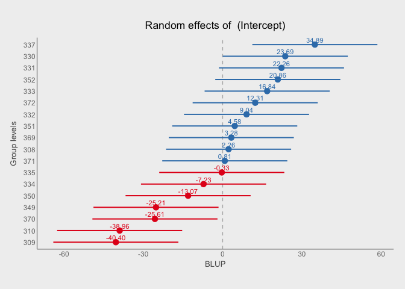

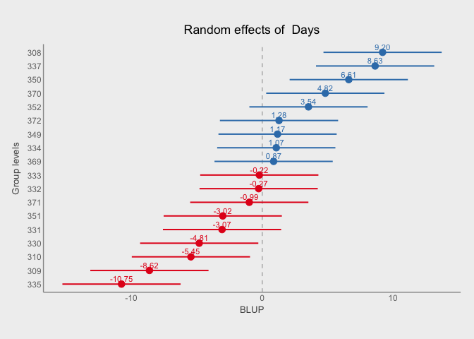

```r
# sort all predictors
sjp.lmer(fit,
         facet.grid = FALSE,
         sort.est = "sort.all",
         y.offset = .4)
```

## Plotting fixed effects slopes for each random intercept (group levels)

To get a better picture of the linear relationship between fixed effects and response depending on the grouping levels (random intercepts), you can plot straight slope lines (*ablines*) for each coefficient with varying random intercepts.

Basically, the formula is `b0 + b0[r1-rn] + bi * xi` (where `xi` is the estimate of fixed effects, `b0` is the intercept of the fixed effects and `b0[r1-rn]` are all random intercepts).

Use `type = "ri.slope"` for this kind of plots. You can select specific grouping levels by their names (or index number) using the `vars`-argument. In this case, only fixed effects indicates in `vars` will be plotted.

```r
# random intercepts
ranef(fit2)
```

```
#> $grp
#>                         (Intercept)
#> spouse/partner           0.62318882
#> child                    0.42390010
#> sibling                 -0.05435509
#> daughter or son -in-law  0.05759517
#> ancle/aunt              -0.10111187
#> nephew/niece            -0.55060420
#> cousin                  -0.11383605
#> other, specify          -0.28477688
```

```r
# fixed effects
fixef(fit2)
```

```
#>  (Intercept)         sex2      c12hour      barthel
#> 14.135947301  0.478500190  0.003365667 -0.047946653
```

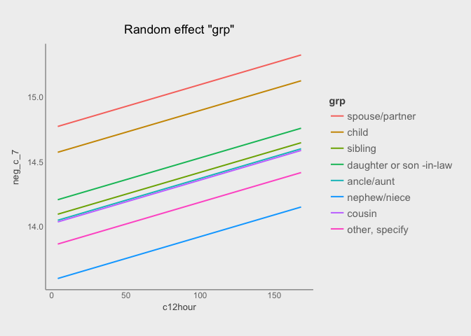

```r
# plot fixed effects depending on group levels
sjp.lmer(fit2, vars = "c12hour", type = "ri.slope")
```

In non-faceted plots, grouping levels might be difficult to distinguish. However, you can emphasize specific groups with `emph.grp`. Note that `emph.grp` only works in non-faceted plots (i.e. `facet.grid = FALSE`)! Remaining (non-emphasized) groups have a light grey color.

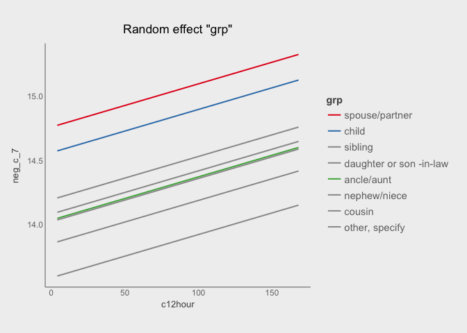

```r
# plot fixed effects depending on group levels
# emphasize group levels 1, 2 and 5
sjp.lmer(fit2,
         type = "ri.slope",
         vars = "c12hour",
         emph.grp = c(1, 2, 5),
         facet.grid = FALSE)
```

## Plotting random slopes depending on random intercepts

Use this plot type to visualize the random parts of random slope-intercept (or repeated measure) models. When having too many groups, use the `sample.n` argument to randomly select a specific amount of subjects.

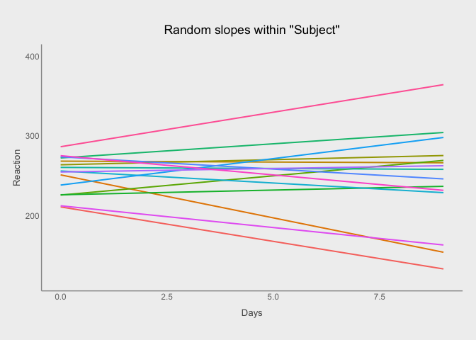

```r
# plot random-slope-intercept
sjp.lmer(fit, type = "rs.ri", vars = "c12hour", sample.n = 15)
```

If `sample.n` is a vector of length greater than one, the specifc “subjects” indicated by `sample.n` are plotted.

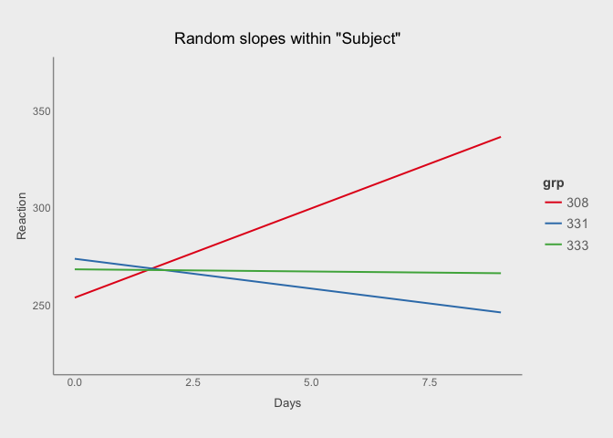

```r
# plot random-slope-intercept, plot subjects 1, 5 and 7.
sjp.lmer(fit, type = "rs.ri",
         sample.n = c(1, 5, 7),
         show.legend = TRUE)
```

### qq-plot of random effects

Another diagnostic plot is the qq-plot for random effects. Use `type = "re.qq"` to plot random against standard quantiles. The dots should be plotted along the line.

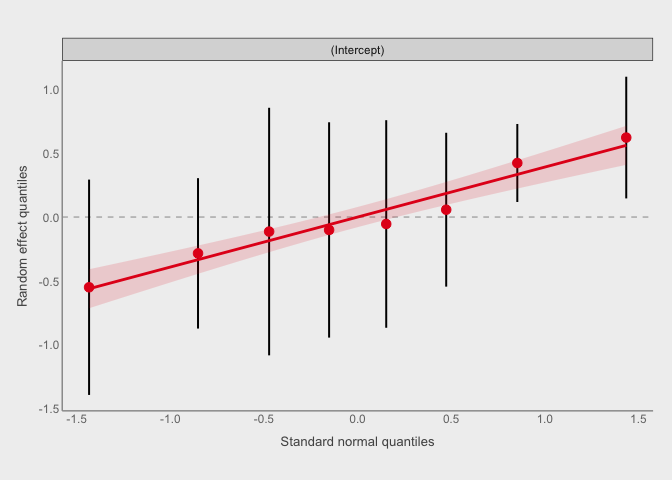

```r
# plot qq-plot of random effects
sjp.lmer(fit2, type = "re.qq")
```

If you have other random effects, like random coefficients, qq-plots for these effects are plotted as well. We refer to the first model to demonstrate this.

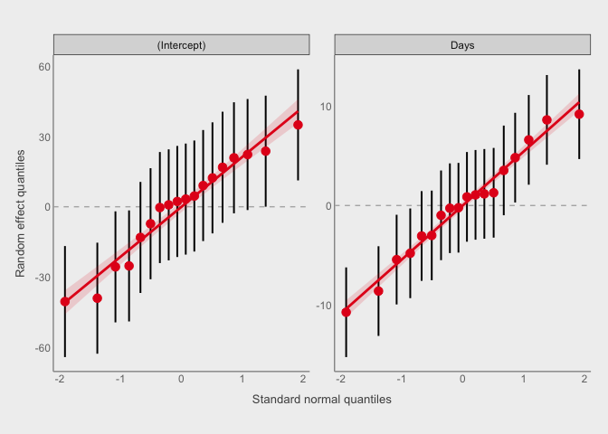

```r
# plot qq-plot of random effects
sjp.lmer(fit, type = "re.qq")
```